# OpenAI SDK Playground

> 📌 **Note:** this notebook does not render well in GitHub. View it in your editor, e.g. VS Code to see the generated content.
- install the required libraries by running `pip install -r requirements.txt`
- create a `.env` file following the pattern in `.env.example`
  - be sure `*.env` is in your `.gitignore` file
  - to do this, you will need an OpenAI API Key.

You'll have to sign up for OpenAI first. At one point they gave some initial free credits. If you do not see those in your account, then the minimum you can pay them is $5 USD. Watch your spend, but $5 USD should be plenty to follow along with the course.. https://platform.openai.com/api-keys

## Guide for creating an API key

You need to sign up first. Once you do that, this video shows how to get an API key. ([video link](https://www.youtube.com/embed/gBSh9JI28UQ?si=1bXff7lMU2eusU-S), in case the embed does not render)

[video not shown]

**Recommended key settings:**

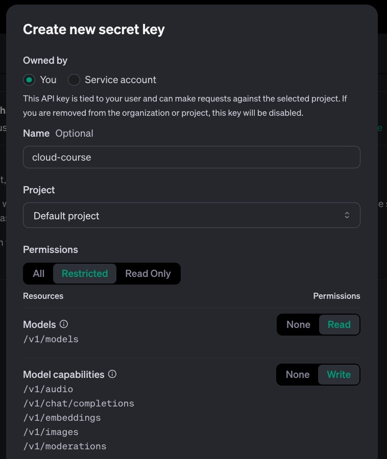

## Install Dependencies

```python
! pip install --upgrade --quiet pip
! pip install --quiet 'openai>=1.35.1,<2' 'python-dotenv>=1.0.1,<2' 'rich>=13.7.1,<14' 'jupyterlab>=4.2.2,<5' 'ipykernel>=6.29.4,<7' 'fastapi>=0.112.0,<1' 'uvicorn>=0.30.6,<0.31'
```

## Imports

```python
# imports - be sure to install the requirements.txt and create a .env file

from pathlib import Path

import IPython
from dotenv import load_dotenv
from openai import AsyncOpenAI
from openai.types.chat import ChatCompletion
from rich import print
```

## Load environment variables from `.env`

The OpenAI Client will implicitly use the OpenAI key loaded from this file because it the env var uses the standard name `OPENAI_API_KEY`.

```python
# Constants

load_dotenv()  # read and export env vars in .env -- the OpenAI client
```

```
True
```

## Text Generation

OpenAPI SDK docs on text generation [here](https://platform.openai.com/docs/guides/text-generation/chat-completions-api).

```python
system_prompt = "You are an autocompletion tool that produces text files given constraints."
prompt = "toml file representing a setuptools python package"

client = AsyncOpenAI()

response: ChatCompletion = await client.chat.completions.create(
    model="gpt-3.5-turbo",
    messages=[
        {"role": "system", "content": system_prompt},
        {"role": "user", "content": prompt},
    ],
    max_tokens=100,  # avoid burning your credits
    n=2,  # number of responses
)

print(response)
```

```
ChatCompletion(
    id='chatcmpl-9wceyQhtlU6Ot2L1q3Ubxi13O2JAY',
    choices=[
        Choice(
            finish_reason='stop',
            index=0,
            logprobs=None,
            message=ChatCompletionMessage(
                content='[metadata]\nname = "yourpackage"\nversion = "0.1.0"\nauthor = "Your Name"\ndescription =
"A short description of your package"\n\n[options]\npackages = ["yourpackage"]\ninstall_requires = [\n
"numpy",\n    "matplotlib"\n]\n\n[options.extras_require]\ndev = [\n    "pytest",\n
"black"\n]\n\n[options.entry_points]\nconsole_scripts =\n    yourscript = yourpackage.script:main',
                refusal=None,
                role='assistant',
                function_call=None,
                tool_calls=None
            )
        ),
        Choice(
            finish_reason='stop',
            index=1,
            logprobs=None,
            message=ChatCompletionMessage(
                content='[build-system]\nrequires = ["setuptools", "wheel"]\nbuild-backend =
"setuptools.build_meta"',
                refusal=None,
                role='assistant',
                function_call=None,
                tool_calls=None
            )
        )
    ],
    created=1723758660,
    model='gpt-3.5-turbo-0125',
    object='chat.completion',
    service_tier=None,
    system_fingerprint=None,
    usage=CompletionUsage(completion_tokens=113, prompt_tokens=33, total_tokens=146)
)
```

## Image Generation

OpenAPI SDK docs on image generation [here](https://platform.openai.com/docs/guides/images/introduction).

```python
client = AsyncOpenAI()

image_response = await client.images.generate(
  model="dall-e-3",
  prompt="minecraft steve learning Python and AWS",
  size="1024x1024",
  quality="standard",
  n=1,
)

print(image_response)
```

```
ImagesResponse(
    created=1723758888,
    data=[
        Image(
            b64_json=None,
            revised_prompt='A character resembling the pixelated style of a popular block-building video game is
seated at a wooden desk in a green grass environment, focusing intently on a glowing computer screen. The
character, possessing short brown hair and a blue t-shirt, appears to be studying Python, as indicated by various
Python coding snippets shown on the screen. Nearby, a book on Amazon Web Services (AWS) lies open, its pages
displaying various diagrams and charts pertaining to cloud servers. Sunlight filters through the nearby trees,
softly illuminating the scene.',
            url='https://oaidalleapiprodscus.blob.core.windows.net/private/org-bC7TsiEXdGsy9GnAiaYaL1bs/user-a3YPb4
2oKPaOtQ9vYeJs3rpL/img-J2l9nNmJvyzG2ZH7dYTewHwM.png?st=2024-08-15T20%3A54%3A48Z&se=2024-08-15T22%3A54%3A48Z&sp=r&sv
=2024-08-04&sr=b&rscd=inline&rsct=image/png&skoid=d505667d-d6c1-4a0a-bac7-5c84a87759f8&sktid=a48cca56-e6da-484e-a81
4-9c849652bcb3&skt=2024-08-15T21%3A01%3A05Z&ske=2024-08-16T21%3A01%3A05Z&sks=b&skv=2024-08-04&sig=vRFsvJlAEDa1ZhYhS
SRqqVYdtueoO3GUNNf3PQoNlis%3D'
        )
    ]
)
```

```python
image_url = image_response.data[0].url

# display the image with max width 400px
IPython.display.Image(url=image_url, width=400)
```

[figure not shown]

[figure not shown]

## Text to speech

OpenAPI SDK docs on text to speech [here](https://platform.openai.com/docs/guides/text-to-speech).

```python
client = AsyncOpenAI()

async with client.audio.speech.with_streaming_response.create(
    model="tts-1",
    voice="echo",
    input="""
    I wanna be the very best
    Like no one ever was
    To catch them is my real test
    To train them is my cause""",
) as response:
    await response.stream_to_file("speech.mp3")
    print(response)
```

```
<AsyncStreamedBinaryAPIResponse [200 OK] type=<class 'bytes'>>
```

```python
IPython.display.Audio("speech.mp3")
```

[interactive chart not shown]

## Mocking OpenAI's REST API using `fastapi`

Next to this notebook there is a file called `openai_fastapi_mock_app.py`.

The cell below starts up an instance of this server in a separate thread.

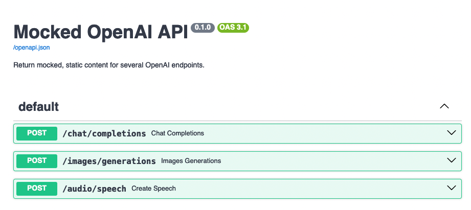

```python
# Start a FastAPI app in the background to mock the OpenAPI API on port 5006

import subprocess
import threading
import sys

MOCKED_OPENAI_PORT = 5006

mocked_openai_api_process = subprocess.Popen(
    [
        # launch the mocked server using python interpreter from the same virtual env used for running the tests
        sys.executable,
        "./openai_fastapi_mock_app.py",
    ],
    stdout=subprocess.PIPE,
    stderr=subprocess.PIPE,
    text=True,
    bufsize=1,
    env={"OPENAI_MOCK_PORT": str(MOCKED_OPENAI_PORT)},
)

# --- steam the log output of the mocked api as it runs --- #

def _stream_output(pipe, name):
    """Stream output from a subprocess pipe."""
    for line in iter(pipe.readline, ""):
        if line:
            print(f"[{name}] {line.strip()}")

stdout_thread = threading.Thread(target=_stream_output, args=(mocked_openai_api_process.stdout, "stdout"))
stderr_thread = threading.Thread(target=_stream_output, args=(mocked_openai_api_process.stderr, "stderr"))
stdout_thread.start()
stderr_thread.start()
```

### Chat completion using mock

```python
from openai.types.chat import ChatCompletion

system_prompt = "You are an autocompletion tool that produces text files given constraints."
prompt = "toml file representing a setuptools python package"

# point to a local mock of OpenAI; this can be done with environment variables as well
client = AsyncOpenAI(base_url=f"http://localhost:{MOCKED_OPENAI_PORT}", api_key="mocked_key")

response: ChatCompletion = await client.chat.completions.create(
    model="gpt-3.5-turbo",
    messages=[
        {"role": "system", "content": system_prompt},
        {"role": "user", "content": prompt},
    ],
    max_tokens=100,  # avoid burning your credits
    n=2,  # number of responses
)

print(response)
```

```
 INFO:     Started server process [93985]
```

```
 INFO:     Waiting for application startup.
```

```
 INFO:     Application startup complete.
```

```
 INFO:     Uvicorn running on http://0.0.0.0:5006 (Press CTRL+C to quit)
```

```
 INFO:     127.0.0.1:57528 - "POST /chat/completions HTTP/1.1" 200 OK
```

```
ChatCompletion(
    id='chatcmpl-6lX3c8j6jNfOo0zHvX56A1E7',
    choices=[
        Choice(
            finish_reason='stop',
            index=0,
            logprobs=None,
            message=ChatCompletionMessage(
                content='This is a mock response from the chat completion endpoint.',
                refusal=None,
                role='assistant',
                function_call=None,
                tool_calls=None
            )
        )
    ],
    created=1677628902,
    model='gpt-4-0314',
    object='chat.completion',
    service_tier=None,
    system_fingerprint=None,
    usage=CompletionUsage(completion_tokens=14, prompt_tokens=9, total_tokens=23)
)
```

### Image generation using mock

```python
# using the same mocked client
client = AsyncOpenAI(base_url=f"http://localhost:{MOCKED_OPENAI_PORT}", api_key="mocked_key")

image_response = await client.images.generate(
  model="dall-e-3",
  prompt="minecraft steve learning Python and AWS",
  size="1024x1024",
  quality="standard",
  n=1,
)

print(image_response)

# display
image_url = image_response.data[0].url
IPython.display.Image(url=image_url, width=400)
```

```
 INFO:     127.0.0.1:57530 - "POST /images/generations HTTP/1.1" 200 OK
```

```
ImagesResponse(
    created=1677628902,
    data=[
        Image(
            b64_json=None,
            revised_prompt=None,
            url='https://repository-images.githubusercontent.com/516708998/571919ae-d303-406d-8098-af4b2d2fb6be'
        )
    ],
    id='imggen-9X3c8j6jNfOo0zHvX56A1E7',
    object='image.generation',
    model='dall-e-2024',
    usage={'prompt_tokens': 15, 'completion_tokens': 1, 'total_tokens': 16}
)
```

[figure not shown]

### Text to speech using mock

```python
client = AsyncOpenAI(base_url=f"http://localhost:{MOCKED_OPENAI_PORT}", api_key="mocked_key")

async with client.audio.speech.with_streaming_response.create(
    model="tts-1",
    voice="echo",
    input="""
    This is dummy input that will not actually
    be transcribed. A pre-set, static audio file will
    be returned instead... you may even recognize it 🤣
    """,
) as response:
    await response.stream_to_file("mocked-speech.mp3")
    print(response)

IPython.display.Audio("mocked-speech.mp3")
```

```
 INFO:     127.0.0.1:57532 - "POST /audio/speech HTTP/1.1" 200 OK
```

```
<AsyncStreamedBinaryAPIResponse [200 OK] type=<class 'bytes'>>
```

[interactive chart not shown]

### Kill the Mocked OpenAPI server started earlier

```python
mocked_openai_api_process.kill()
mocked_openai_api_process.wait()
```

```
-9
```